# Food Deserts Analysis

Team 1 : Abishek Chiffon, Keerthana Aravindhan, Mowzli Sre Mohan Dass, Robert Williams

2023-12-14

# Introduction

1. Exposition and Curation
1. What do we know about this dataset?

This information on supermarket availability at different distances was taken from the Food Access Research Atlas. This data gives a rich detailed summary because it measures access by the Census-Tract. Data on food access was linked with information on age, race, location (rural or urban), and income.

2. What are the limitations of the dataset?

The dataset lacks variables to monitor the median household income and vehicle accessibility across different ethnic groups. It is crucial to note that the term “vehicle access” in this context does not necessarily imply the absence of vehicles at a residence; rather, individuals are deemed to have access to a vehicle if public transportation is readily available to them. Additionally, there are no variables present to explicitly denote households without any vehicles.

# Data Loading and Preprocessing

```r
# Loading data
data <- data.frame(read.csv("FoodDesert2015.csv"))
knitr::kable(head(data, 5), format ='markdown')
```

| CensusTract | State | County | Urban | POP2010 | OHU2010 | GroupQuartersFlag | NUMGQTRS | PCTGQTRS | LILATracts_1And10 | LILATracts_halfAnd10 | LILATracts_1And20 | LILATracts_Vehicle | HUNVFlag | LowIncomeTracts | PovertyRate | MedianFamilyIncome | LA1and10 | LAhalfand10 | LA1and20 | LATracts_half | LATracts1 | LATracts10 | LATracts20 | LATractsVehicle_20 | LAPOP1_10 | LAPOP05_10 | LAPOP1_20 | LALOWI1_10 | LALOWI05_10 | … |
| --- | --- | --- | --- | --- | --- | --- | --- | --- | --- | --- | --- | --- | --- | --- | --- | --- | --- | --- | --- | --- | --- | --- | --- | --- | --- | --- | --- | --- | --- | --- |
| 1.001e+09 | Alabama | Autauga | 1 | 1912 | 693 | 0 | 0 | 0.00000 | 0 | 0 | 0 | 0 | 0 | 0 | 10.0 | 74750 | 1 | 1 | 1 | 1 | 1 | 0 | 0 | 0 | 1357.48 | 1732.2 | 1357.48 | 322.08 | 411.69 | … |
| 1.001e+09 | Alabama | Autauga | 1 | 2170 | 743 | 0 | 181 | 0.08341 | 0 | 0 | 0 | 0 | 0 | 0 | 18.2 | 51875 | 0 | 1 | 0 | 1 | 0 | 0 | 0 | 0 | 483.43 | 1410.4 | 483.43 | 145.14 | 475.31 | … |
| 1.001e+09 | Alabama | Autauga | 1 | 3373 | 1256 | 0 | 0 | 0.00000 | 0 | 0 | 0 | 0 | 0 | 0 | 19.1 | 52905 | 1 | 1 | 1 | 1 | 1 | 0 | 0 | 0 | 1417.87 | 2764.6 | 1417.87 | 696.64 | 1350.18 | … |
| 1.001e+09 | Alabama | Autauga | 1 | 4386 | 1722 | 0 | 0 | 0.00000 | 0 | 0 | 0 | 0 | 0 | 0 | 3.3 | 68079 | 1 | 1 | 1 | 1 | 1 | 0 | 0 | 0 | 1363.47 | 3651.1 | 1363.47 | 409.59 | 1067.84 | … |
| 1.001e+09 | Alabama | Autauga | 1 | 10766 | 4082 | 0 | 181 | 0.01681 | 0 | 0 | 0 | 0 | 1 | 0 | 8.5 | 77819 | 1 | 1 | 1 | 1 | 1 | 0 | 0 | 1 | 2643.10 | 7778.4 | 2643.10 | 623.08 | 1913.45 | … |

## Summary of the dataset:

```r
str(data)
```

```
## 'data.frame':    72864 obs. of  147 variables:
##  $ CensusTract         : num  1e+09 1e+09 1e+09 1e+09 1e+09 ...
##  $ State               : chr  "Alabama" "Alabama" "Alabama" "Alabama" ...
##  $ County              : chr  "Autauga" "Autauga" "Autauga" "Autauga" ...
##  $ Urban               : int  1 1 1 1 1 1 1 0 0 0 ...
##  $ POP2010             : int  1912 2170 3373 4386 10766 3668 2891 3081 10435 5675 ...
##  $ OHU2010             : int  693 743 1256 1722 4082 1311 1188 1074 3694 2067 ...
##  $ GroupQuartersFlag   : int  0 0 0 0 0 0 0 0 0 0 ...
##  $ NUMGQTRS            : int  0 181 0 0 181 0 36 0 0 14 ...
##  $ PCTGQTRS            : num  0 0.0834 0 0 0.0168 ...
##  $ LILATracts_1And10   : int  0 0 0 0 0 0 1 0 0 0 ...
##  $ LILATracts_halfAnd10: int  0 0 0 0 0 0 1 0 0 0 ...
##  $ LILATracts_1And20   : int  0 0 0 0 0 0 1 0 0 0 ...
##  $ LILATracts_Vehicle  : int  0 0 0 0 0 0 1 0 0 0 ...
##  $ HUNVFlag            : int  0 0 0 0 1 0 1 1 0 0 ...
```

[output cut: 86 more lines]

```r
summary(data)
```

```
##   CensusTract          State              County              Urban
##  Min.   :1.00e+09   Length:72864       Length:72864       Min.   :0.000
##  1st Qu.:1.21e+10   Class :character   Class :character   1st Qu.:1.000
##  Median :2.71e+10   Mode  :character   Mode  :character   Median :1.000
##  Mean   :2.78e+10                                         Mean   :0.757
##  3rd Qu.:4.10e+10                                         3rd Qu.:1.000
##  Max.   :5.60e+10                                         Max.   :1.000
##     POP2010         OHU2010      GroupQuartersFlag    NUMGQTRS
##  Min.   :    0   Min.   :    0   Min.   :0.00000   Min.   :    0
##  1st Qu.: 2884   1st Qu.: 1102   1st Qu.:0.00000   1st Qu.:    0
##  Median : 4002   Median : 1521   Median :0.00000   Median :    7
##  Mean   : 4237   Mean   : 1602   Mean   :0.00708   Mean   :  110
##  3rd Qu.: 5323   3rd Qu.: 2018   3rd Qu.:0.00000   3rd Qu.:   63
##  Max.   :37452   Max.   :16043   Max.   :1.00000   Max.   :19496
##     PCTGQTRS       LILATracts_1And10 LILATracts_halfAnd10 LILATracts_1And20
##  Min.   :0.00000   Min.   :0.000     Min.   :0.000        Min.   :0.000
##  1st Qu.:0.00000   1st Qu.:0.000     1st Qu.:0.000        1st Qu.:0.000
##  Median :0.00178   Median :0.000     Median :0.000        Median :0.000
##  Mean   :0.02696   Mean   :0.127     Mean   :0.282        Mean   :0.111
##  3rd Qu.:0.01552   3rd Qu.:0.000     3rd Qu.:1.000        3rd Qu.:0.000
##  Max.   :1.00000   Max.   :1.000     Max.   :1.000        Max.   :1.000
##  LILATracts_Vehicle    HUNVFlag     LowIncomeTracts  PovertyRate
##  Min.   :0.000      Min.   :0.000   Min.   :0.000   Min.   :  0.0
##  1st Qu.:0.000      1st Qu.:0.000   1st Qu.:0.000   1st Qu.:  7.0
##  Median :0.000      Median :0.000   Median :0.000   Median : 13.2
##  Mean   :0.149      Mean   :0.224   Mean   :0.424   Mean   : 16.6
##  3rd Qu.:0.000      3rd Qu.:0.000   3rd Qu.:1.000   3rd Qu.: 22.7
##  Max.   :1.000      Max.   :1.000   Max.   :1.000   Max.   :100.0
##  MedianFamilyIncome    LA1and10      LAhalfand10       LA1and20
##  Min.   :     0     Min.   :0.000   Min.   :0.000   Min.   :0.000
##  1st Qu.: 44837     1st Qu.:0.000   1st Qu.:0.000   1st Qu.:0.000
##  Median : 60893     Median :0.000   Median :1.000   Median :0.000
##  Mean   : 67432     Mean   :0.378   Mean   :0.682   Mean   :0.339
##  3rd Qu.: 82763     3rd Qu.:1.000   3rd Qu.:1.000   3rd Qu.:1.000
##  Max.   :250000     Max.   :1.000   Max.   :1.000   Max.   :1.000
##  LATracts_half     LATracts1       LATracts10      LATracts20
##  Min.   :0.000   Min.   :0.000   Min.   :0.000   Min.   :0.00000
##  1st Qu.:0.000   1st Qu.:0.000   1st Qu.:0.000   1st Qu.:0.00000
##  Median :1.000   Median :0.000   Median :0.000   Median :0.00000
##  Mean   :0.638   Mean   :0.334   Mean   :0.044   Mean   :0.00532
```

[output cut: 204 more lines]

```
##  Max.   :11845   Max.   :17271   Max.   :28983   Max.   :16804
##    TractAsian      TractNHOPI       TractAIAN       TractOMultir
##  Min.   :    0   Min.   :   0.0   Min.   :   0.0   Min.   :   0
##  1st Qu.:   17   1st Qu.:   0.0   1st Qu.:   7.0   1st Qu.:  83
##  Median :   57   Median :   1.0   Median :  15.0   Median : 184
##  Mean   :  201   Mean   :   7.4   Mean   :  40.2   Mean   : 386
##  3rd Qu.:  188   3rd Qu.:   5.0   3rd Qu.:  33.0   3rd Qu.: 446
##  Max.   :10485   Max.   :3491.0   Max.   :9009.0   Max.   :8839
##  TractHispanic     TractHUNV      TractSNAP
##  Min.   :    0   Min.   :   0   Min.   :   0
##  1st Qu.:   87   1st Qu.:  37   1st Qu.:  69
##  Median :  240   Median :  84   Median : 158
##  Mean   :  693   Mean   : 145   Mean   : 207
##  3rd Qu.:  746   3rd Qu.: 172   3rd Qu.: 293
##  Max.   :15420   Max.   :6176   Max.   :2152
```

### Data Preprocessing:

Factorizing Categorical variable

```r
data$LILATracts_1And10 <- as.factor(data$LILATracts_1And10)
data$GroupQuartersFlag <- as.factor(data$GroupQuartersFlag)
data$Urban = as.factor(data$Urban)
data$LILATracts_halfAnd10 = as.factor(data$LILATracts_halfAnd10)
data$LILATracts_1And20 = as.factor(data$LILATracts_1And20)
data$LILATracts_Vehicle = as.factor(data$LILATracts_Vehicle)
data$HUNVFlag = as.factor(data$HUNVFlag)
data$LowIncomeTracts = as.factor(data$LowIncomeTracts)
data$LA1and10 = as.factor(data$LA1and10)
data$LAhalfand10 = as.factor(data$LAhalfand10)
data$LA1and20 = as.factor(data$LA1and20)
data$LATracts_half = as.factor(data$LATracts_half)
data$LATracts1 = as.factor(data$LATracts1)
data$LATracts10 = as.factor(data$LATracts10)
data$LATracts20 = as.factor(data$LATracts20)
data$LATractsVehicle_20 = as.factor(data$LATractsVehicle_20)
str(data)
```

```
## 'data.frame':    72864 obs. of  147 variables:
##  $ CensusTract         : num  1e+09 1e+09 1e+09 1e+09 1e+09 ...
##  $ State               : chr  "Alabama" "Alabama" "Alabama" "Alabama" ...
##  $ County              : chr  "Autauga" "Autauga" "Autauga" "Autauga" ...
##  $ Urban               : Factor w/ 2 levels "0","1": 2 2 2 2 2 2 2 1 1 1 ...
##  $ POP2010             : int  1912 2170 3373 4386 10766 3668 2891 3081 10435 5675 ...
##  $ OHU2010             : int  693 743 1256 1722 4082 1311 1188 1074 3694 2067 ...
##  $ GroupQuartersFlag   : Factor w/ 2 levels "0","1": 1 1 1 1 1 1 1 1 1 1 ...
##  $ NUMGQTRS            : int  0 181 0 0 181 0 36 0 0 14 ...
##  $ PCTGQTRS            : num  0 0.0834 0 0 0.0168 ...
##  $ LILATracts_1And10   : Factor w/ 2 levels "0","1": 1 1 1 1 1 1 2 1 1 1 ...
##  $ LILATracts_halfAnd10: Factor w/ 2 levels "0","1": 1 1 1 1 1 1 2 1 1 1 ...
##  $ LILATracts_1And20   : Factor w/ 2 levels "0","1": 1 1 1 1 1 1 2 1 1 1 ...
##  $ LILATracts_Vehicle  : Factor w/ 2 levels "0","1": 1 1 1 1 1 1 2 1 1 1 ...
##  $ HUNVFlag            : Factor w/ 2 levels "0","1": 1 1 1 1 2 1 2 2 1 1 ...
```

[output cut: 86 more lines]

# EDA and Inference of LILA tract:

## Median Family Income Analysis

From the Project 1, we learned that Median Family Income is an important feature contributing to the prevalence of a region being a food desert. To further investigate this, we conducted a t-test over the `MedianFamilyIncome` variable.

```r
# Set thresholds for defining potential food deserts
poverty_rate_threshold <- 20  # percent
median_income_threshold <- quantile(data$MedianFamilyIncome, 0.25)  # lower quartile
snap_beneficiary_threshold <- 20  # percent

# Creating a food desert indicator
data$PotentialFoodDesert <- with(data,
  (PovertyRate >= poverty_rate_threshold) &
  (MedianFamilyIncome <= median_income_threshold) &
  (TractSNAP / POP2010 * 100 >= snap_beneficiary_threshold)
)

# Calculating average median family income for potential food desert areas and non-food desert areas
average_income_food_desert <- mean(data[data$PotentialFoodDesert, "MedianFamilyIncome"])
average_income_non_food_desert <- mean(data[!data$PotentialFoodDesert, "MedianFamilyIncome"])

# Performing a t-test to check if the difference in median family incomes is statistically significant
t_test_result <- t.test(
  data[data$PotentialFoodDesert, "MedianFamilyIncome"],
  data[!data$PotentialFoodDesert, "MedianFamilyIncome"]
)

# Print the results
cat("Average Median Family Income in Potential Food Deserts:", average_income_food_desert, "\n")
```

```
## Average Median Family Income in Potential Food Deserts: 22544
```

```r
cat("Average Median Family Income in Non-Food Desert Areas:", average_income_non_food_desert, "\n")
```

```
## Average Median Family Income in Non-Food Desert Areas: 67928
```

```r
cat("T-Test Results:\n")
```

```
## T-Test Results:
```

```r
print(t_test_result)
```

```
##
##  Welch Two Sample t-test
##
## data:  data[data$PotentialFoodDesert, "MedianFamilyIncome"] and data[!data$PotentialFoodDesert, "MedianFamilyIncome"]
## t = -150, df = 1164, p-value <2e-16
## alternative hypothesis: true difference in means is not equal to 0
## 95 percent confidence interval:
##  -45978 -44788
## sample estimates:
## mean of x mean of y
##     22544     67928
```

### T-Test Results

The t-test was conducted to assess the difference in median family incomes between potential food desert areas and non-food desert areas. Here are the results:

Average Median Family Income in Potential Food Deserts: **$22,544.33** Average Median Family Income in Non-Food Desert Areas: **$67,927.53**

The t-test resulted in a t-statistic of **-149.61** and a p-value of **< 2.2e-16**. The small p-value suggests a significant difference in median family incomes between potential food desert and non-food desert areas.

**Inference:**

Based on the t-test results, we can conclude that there is a statistically significant difference in median family incomes between potential food desert areas and non-food desert areas. Areas classified as potential food deserts tend to have lower median family incomes.

```r
logistic_model <- glm(
  PotentialFoodDesert ~ MedianFamilyIncome,
  data = data,
  family = binomial
)

# Summarize the logistic regression results
summary(logistic_model)
```

```
##
## Call:
## glm(formula = PotentialFoodDesert ~ MedianFamilyIncome, family = binomial,
##     data = data)
##
## Coefficients:
##                     Estimate Std. Error z value Pr(>|z|)
## (Intercept)        -8.48e-01   6.34e-02   -13.4   <2e-16 ***
## MedianFamilyIncome -8.85e-05   2.04e-06   -43.4   <2e-16 ***
## ---
## Signif. codes:  0 '***' 0.001 '**' 0.01 '*' 0.05 '.' 0.1 ' ' 1
##
## (Dispersion parameter for binomial family taken to be 1)
##
##     Null deviance: 8773.9  on 72863  degrees of freedom
## Residual deviance: 6233.0  on 72862  degrees of freedom
## AIC: 6237
##
## Number of Fisher Scoring iterations: 9
```

```r
exp(coef(logistic_model))
```

```
##        (Intercept) MedianFamilyIncome
##            0.42842            0.99991
```

### Logistic Regression Results

A logistic regression model was employed to further investigate the relationship between MedianFamilyIncome and the likelihood of an area being a potential food desert. Here are the results:

### Effect of a $1,000 Increase in Median Family Income

To understand the effect of a **$1,000** increase in median family income, we can calculate the change in odds:

This analysis highlights the importance of `MedianFamilyIncome` in determining the likelihood of an area being classified as a potential food desert. Higher median family incomes are associated with a reduced likelihood of an area being a potential food desert.

## Impact of GroupQuarters on Food desert:

### Chi sq test analysis:

chi-square (GOF) test between 2 categorical variables (GroupQuartersFlag and LILATracts_1And10):

- Null Hypothesis (H0): There is no association between the two categorical variables
- Alternative Hypothesis (H1): There is an association between the two categorical variables

Significance level $\alpha$ = 0.05

```r
# creating contingency table
contingency_table <- table(data$GroupQuartersFlag, data$LILATracts_1And10)
# executing chi sq test
chi_squared_test_result <- chisq.test(contingency_table)
chi_squared_test_result
```

```
##
##  Pearson's Chi-squared test with Yates' continuity correction
##
## data:  contingency_table
## X-squared = 37.3, df = 1, p-value = 1e-09
```

Due to the extremely low p value, H0 is rejected. Therefore, there is a **significant association or correlation** between “GroupQuartersFlag” and “LILATracts_1And10.”

### Graph analysis:

```r
GroupQuarters_LILA <- data[ (data$GroupQuartersFlag == 1 & data$LILATracts_1And10 == 1), c("GroupQuartersFlag", "LILATracts_1And10")]
NonGroupQuarters_LILA <- data[data$GroupQuartersFlag == 0 & data$LILATracts_1And10 == 1, c("GroupQuartersFlag", "LILATracts_1And10")]

data1 = data.frame()
Percentage_GroupQuarters_LILA = nrow(GroupQuarters_LILA)/(nrow(GroupQuarters_LILA)+ nrow(NonGroupQuarters_LILA))*100
Percentage_NonGroupQuarters_LILA = nrow(NonGroupQuarters_LILA)/(nrow(GroupQuarters_LILA)+ nrow(NonGroupQuarters_LILA))*100
data1 <- rbind(data1, Percentage_GroupQuarters_LILA)
data1 <- rbind(data1, Percentage_NonGroupQuarters_LILA)
GroupQuartersFlag = c(1,0)
data1 <- cbind(data1, GroupQuartersFlag)
colnames(data1) <- c('Percentage', 'GroupQuartersFlag')
```

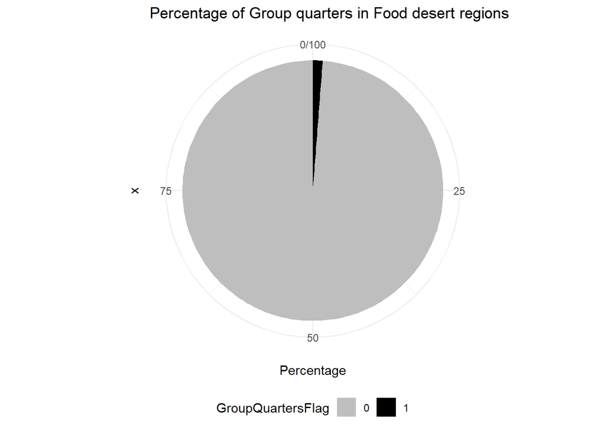

```r
library(ggplot2)
pie_chart <- ggplot(data1, aes(x = "", y = Percentage, fill = factor(GroupQuartersFlag))) +
  geom_bar(stat = "identity", width = 1) +
  coord_polar(theta = "y") +
  labs(title = "Percentage of Group quarters in Food desert regions",
       fill = "GroupQuartersFlag") +
  scale_fill_manual(values = c("0" = "grey", "1" = "black"), labels = c("0", "1")) +
  theme_minimal() +
  theme(legend.position = "bottom")
print(pie_chart)
```

The pie chart clearly illustrates that within food desert regions, the percentage of Group Quarters is significantly lower when compared to Non-Group Quarters.

```r
GroupQuarters_NonLILA <- data[ (data$GroupQuartersFlag == 1 & data$LILATracts_1And10 == 0), c("GroupQuartersFlag", "LILATracts_1And10")]
NonGroupQuarters_NonLILA <- data[ (data$GroupQuartersFlag == 0 & data$LILATracts_1And10 == 0), c("GroupQuartersFlag", "LILATracts_1And10")]

data1 = data.frame()
Percentage_GroupQuarters_NonLILA = nrow(GroupQuarters_NonLILA)/(nrow(GroupQuarters_NonLILA)+ nrow(NonGroupQuarters_NonLILA))*100
Percentage_NonGroupQuarters_NonLILA = nrow(NonGroupQuarters_NonLILA)/(nrow(GroupQuarters_NonLILA)+ nrow(NonGroupQuarters_NonLILA))*100
data1 <- rbind(data1, Percentage_GroupQuarters_NonLILA)
data1 <- rbind(data1, Percentage_NonGroupQuarters_NonLILA)
GroupQuartersFlag = c(0,1)
data1 <- cbind(data1, GroupQuartersFlag)
colnames(data1) <- c('Percentage', 'GroupQuartersFlag')
```

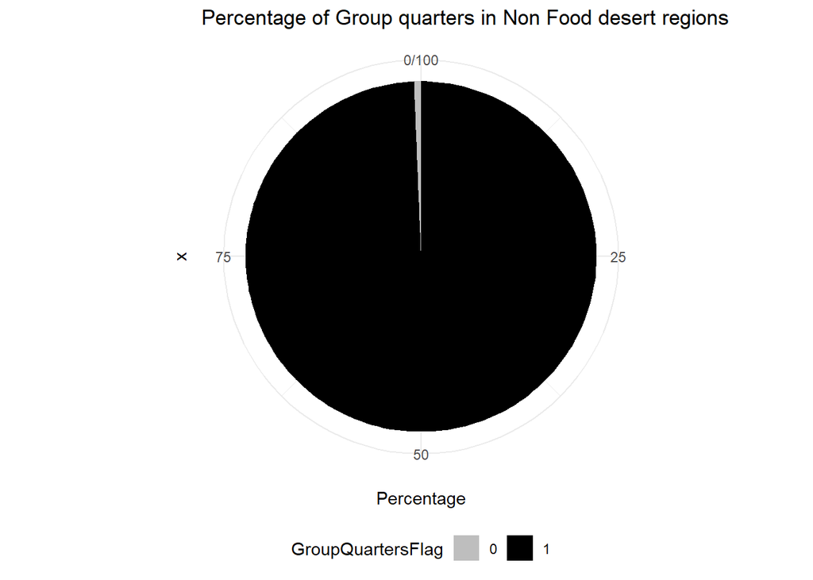

```r
library(ggplot2)
pie_chart <- ggplot(data1, aes(x = "", y = Percentage, fill = factor(GroupQuartersFlag))) +
  geom_bar(stat = "identity", width = 1) +
  coord_polar(theta = "y") +
  labs(title = "Percentage of Group quarters in Non Food desert regions",
       fill = "GroupQuartersFlag") +
  scale_fill_manual(values = c("0" = "grey", "1" = "black"), labels = c("0", "1")) +
  theme_minimal() +
  theme(legend.position = "bottom")
print(pie_chart)
```

### Inference about Group Quarters on Food desert:

```r
model1 <- glm(LILATracts_1And10 ~ PovertyRate + GroupQuartersFlag, family = binomial(link = "logit"), data = data)
summary(model1)
```

```
##
## Call:
## glm(formula = LILATracts_1And10 ~ PovertyRate + GroupQuartersFlag,
##     family = binomial(link = "logit"), data = data)
##
## Coefficients:
##                     Estimate Std. Error z value Pr(>|z|)
## (Intercept)        -3.041378   0.021507 -141.41   <2e-16 ***
## PovertyRate         0.055816   0.000791   70.57   <2e-16 ***
## GroupQuartersFlag1 -0.643663   0.144177   -4.46    8e-06 ***
## ---
## Signif. codes:  0 '***' 0.001 '**' 0.01 '*' 0.05 '.' 0.1 ' ' 1
##
## (Dispersion parameter for binomial family taken to be 1)
##
##     Null deviance: 55437  on 72863  degrees of freedom
## Residual deviance: 50195  on 72861  degrees of freedom
## AIC: 50201
##
## Number of Fisher Scoring iterations: 5
```

GroupQuartersFlag = 1 is associated with a decrease of 0.643663 in the log-odds of the response variable (LILATracts_1And10) being 1. The coefficient is significant (p-value = 8e-06).

```r
expcoeff = exp(coef(model1))
#expcoeff
xkabledply(as.table(expcoeff), title = "Exponential of coefficients in Logit Reg" )
```

Exponential of coefficients in Logit Reg

|  | x |
| --- | --- |
| (Intercept) | 0.0478 |
| PovertyRate | 1.0574 |
| GroupQuartersFlag1 | 0.5254 |

The effect of being in GroupQuartersFlag = 1, compared to GroupQuartersFlag = 0, is hurting by a factor of 0.5254, for the log(odds-ratio). Any factor less than 1 represents a negative effect.

`Analysis` :

Hence, insights drawn from both graphical representation and logistic regression models converge to indicate that `GroupQuartersflag negatively affect the Food deserts.

## Impact of GroupQuarters and poverty rate together on Food desert:

SMART Question : Can we quantify the impact of the “PovertyRate” and “Group Quarters” on the likelihood of a census tract being classified as a food desert?

### Graph analysis:

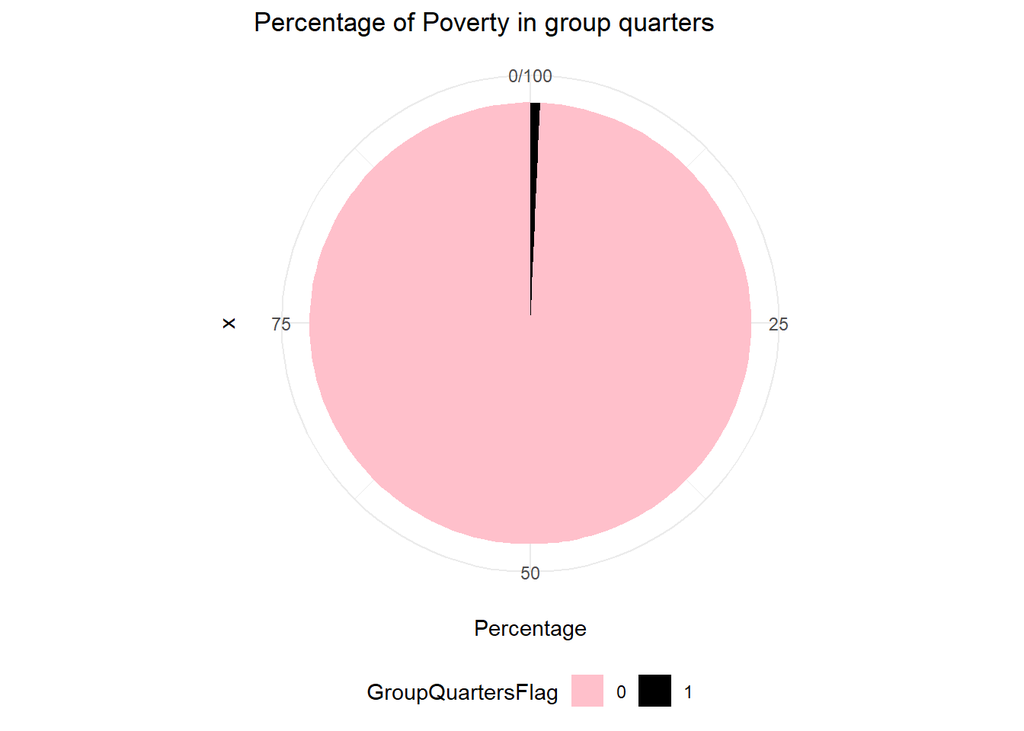

```r
data2 = data.frame()
Percentage_GroupQuarters_Poverty = nrow(GroupQuarters_Poverty)/(sum(nrow(GroupQuarters_Poverty)+ nrow(NonGroupQuarters_Poverty)))*100
Percentage_NonGroupQuarters_Poverty = nrow(NonGroupQuarters_Poverty)/(sum(nrow(GroupQuarters_Poverty)+ nrow(NonGroupQuarters_Poverty)))*100
data2 <- rbind(data2, Percentage_GroupQuarters_Poverty)
data2 <- rbind(data2, Percentage_NonGroupQuarters_Poverty)
GroupQuartersFlag = c(1,0)
data2 <- cbind(data2, GroupQuartersFlag)
colnames(data2) <- c('Percentage', 'GroupQuartersFlag')

pie_chart <- ggplot(data2, aes(x = "", y = Percentage, fill = factor(GroupQuartersFlag))) +
  geom_bar(stat = "identity", width = 1) +
  coord_polar(theta = "y") +
  labs(title = "Percentage of Poverty in group quarters",
       fill = "GroupQuartersFlag") +
  scale_fill_manual(values = c("0" = "pink", "1" = "black"), labels = c("0", "1")) +
  theme_minimal() +
  theme(legend.position = "bottom")
print(pie_chart)
```

Analysis of the pie chart reveals that Non-Group Quarters tracts exhibit a higher poverty rate compared to Group Quarters tracts.

### Interaction term between group quarters and poverty rate - inference:

```r
model2 <- glm(LILATracts_1And10 ~ PovertyRate * GroupQuartersFlag, family = binomial(link = "logit"), data = data)
summary(model2)
```

```
##
## Call:
## glm(formula = LILATracts_1And10 ~ PovertyRate * GroupQuartersFlag,
##     family = binomial(link = "logit"), data = data)
##
## Coefficients:
##                                 Estimate Std. Error z value Pr(>|z|)
## (Intercept)                    -3.069800   0.021849 -140.50  < 2e-16 ***
## PovertyRate                     0.057060   0.000804   70.95  < 2e-16 ***
## GroupQuartersFlag1              0.843535   0.186206    4.53  5.9e-06 ***
## PovertyRate:GroupQuartersFlag1 -0.031429   0.003459   -9.09  < 2e-16 ***
## ---
## Signif. codes:  0 '***' 0.001 '**' 0.01 '*' 0.05 '.' 0.1 ' ' 1
##
## (Dispersion parameter for binomial family taken to be 1)
##
##     Null deviance: 55437  on 72863  degrees of freedom
## Residual deviance: 50126  on 72860  degrees of freedom
## AIC: 50134
##
## Number of Fisher Scoring iterations: 5
```

- In Non GroupQuarters (GroupQuartersFlag is 0), one unit increase in PovertyRate is associated with a relatively larger increase (0.0570596) in the log-odds of the response variable being 1.
- In GroupQuarters (GroupQuartersFlag is 1), one unit increase in PovertyRate is associated with smaller increase (0.026) in the log-odds of the response variable being 1.

```r
expcoeff = exp(coef(model2))
#expcoeff
xkabledply(as.table(expcoeff), title = "Exponential of coefficients in Logit Reg" )
```

Exponential of coefficients in Logit Reg

|  | x |
| --- | --- |
| (Intercept) | 0.0464 |
| PovertyRate | 1.0587 |
| GroupQuartersFlag1 | 2.3246 |
| PovertyRate:GroupQuartersFlag1 | 0.9691 |

`Analysis` :

- Through EDA and consideration of interaction terms, it becomes evident that a one-unit increase in the poverty rate within Non-Group Quarters has a more substantial impact on the prevalence of food deserts compared to a one-unit increase in the poverty rate within Group Quarters.
- Consequently, relationship between PovertyRate and the odds of the Food desert is influenced by the presence of GroupQuartersFlag.`

## Impact of GroupQuarters and Urban together on Food desert:

### Graph analysis:

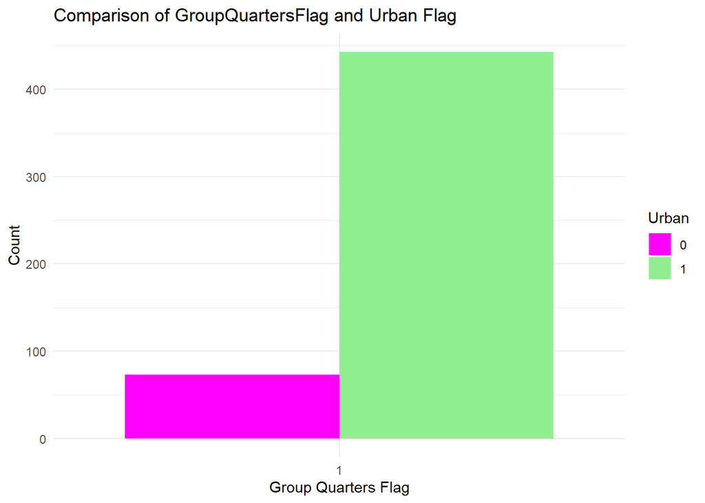

```r
GroupQuarters <- data[data$GroupQuartersFlag == 1, c("GroupQuartersFlag", "Urban")]

bar_chart <- ggplot(GroupQuarters, aes(x = GroupQuartersFlag, fill = Urban)) +
  geom_bar(position = "dodge") +
  labs(title = "Comparison of GroupQuartersFlag and Urban Flag",
       x = "Group Quarters Flag",
       y = "Count") +
  scale_fill_manual(values = c("1" = "lightgreen", "0" = "magenta")) +
  theme_minimal()

print(bar_chart)
```

The bar chart highlights a higher prevalence of Group Quarters in Urban areas than in Rural.

### Interaction term between group quarters and Urban - inference:

```r
model3 <- glm(LILATracts_1And10 ~ GroupQuartersFlag * Urban, family = binomial(link = "logit"), data = data)
summary(model3)
```

```
##
## Call:
## glm(formula = LILATracts_1And10 ~ GroupQuartersFlag * Urban,
##     family = binomial(link = "logit"), data = data)
##
## Coefficients:
##                           Estimate Std. Error z value Pr(>|z|)
## (Intercept)                -2.5013     0.0285  -87.86   <2e-16 ***
## GroupQuartersFlag1         -0.1088     0.4642   -0.23     0.81
## Urban1                      0.7064     0.0310   22.80   <2e-16 ***
## GroupQuartersFlag1:Urban1   0.7593     0.4775    1.59     0.11
## ---
## Signif. codes:  0 '***' 0.001 '**' 0.01 '*' 0.05 '.' 0.1 ' ' 1
##
## (Dispersion parameter for binomial family taken to be 1)
##
##     Null deviance: 55437  on 72863  degrees of freedom
## Residual deviance: 54798  on 72860  degrees of freedom
## AIC: 54806
##
## Number of Fisher Scoring iterations: 5
```

- In non-urban areas, the presence of group quarters (GroupQuartersFlag1) is not statistically significant in predicting the log-odds of the response variable being 1.
- In urban areas, the presence of group quarters (GroupQuartersFlag1) is associated with an increase in the log-odds of the response variable being 1. However, the statistical significance of this effect is not strong based on the p-value.

```r
expcoeff = exp(coef(model3))
#expcoeff
xkabledply(as.table(expcoeff), title = "Exponential of coefficients in Logit Reg" )
```

Exponential of coefficients in Logit Reg

|  | x |
| --- | --- |
| (Intercept) | 0.0820 |
| GroupQuartersFlag1 | 0.8969 |
| Urban1 | 2.0268 |
| GroupQuartersFlag1:Urban1 | 2.1369 |

The log(odds-ratio) for a tract to be food desert is improved by a factor of 2.13688 for GroupQuartersFlag = 1 when Urban1 is 1 compared to when it is 0.

## Impact of Urban on Food desert:

```r
model4 <- glm(LILATracts_1And10 ~ Urban, family = binomial(link = "logit"), data = data)
summary(model4)
```

```
##
## Call:
## glm(formula = LILATracts_1And10 ~ Urban, family = binomial(link = "logit"),
##     data = data)
##
## Coefficients:
##             Estimate Std. Error z value Pr(>|z|)
## (Intercept)  -2.5017     0.0284   -88.0   <2e-16 ***
## Urban1        0.7134     0.0309    23.1   <2e-16 ***
## ---
## Signif. codes:  0 '***' 0.001 '**' 0.01 '*' 0.05 '.' 0.1 ' ' 1
##
## (Dispersion parameter for binomial family taken to be 1)
##
##     Null deviance: 55437  on 72863  degrees of freedom
## Residual deviance: 54829  on 72862  degrees of freedom
## AIC: 54833
##
## Number of Fisher Scoring iterations: 5
```

```r
expcoeff = exp(coef(model4))
#expcoeff
xkabledply(as.table(expcoeff), title = "Exponential of coefficients in Logit Reg" )
```

Exponential of coefficients in Logit Reg

|  | x |
| --- | --- |
| (Intercept) | 0.0819 |
| Urban1 | 2.0408 |

`Analysis`

The effect of a tract being food desert from Urban area, compared to Rural, is associated with a statistically significant increase by a factor of 2.041, for the log(odds-ratio).

# Predicting Food desert:

## GLM model for food desert

The variable denoting a tract being a food desert is LILATracts_1And10. We initially created a logistic regression model for food desert from the variables we got from the EDA we did in the first project. We found all these variables has significant effect on a tract being a food desert. Variables : “Urban”,“GroupQuartersFlag”,“LowIncomeTracts”,“lahunv1share”,“PCTGQTRS”,“MedianFamilyIncome”,“lawhite1”,“lablack1”,“laasian1”,“lahisp1”,“lanhopi1”,“laomultir1”,“laaian1”,“lakids10”,“lakids1”,“TractKids”,“laseniors1”,“laseniors10”,“TractKids”,“TractSeniors”,“TractWhite”,“TractBlack”,“TractAsian”,“TractNHOPI”,“TractAIAN”,“TractOMultir”,“TractHispanic”,“TractHUNV”,“TractSNAP”, “PovertyRate”

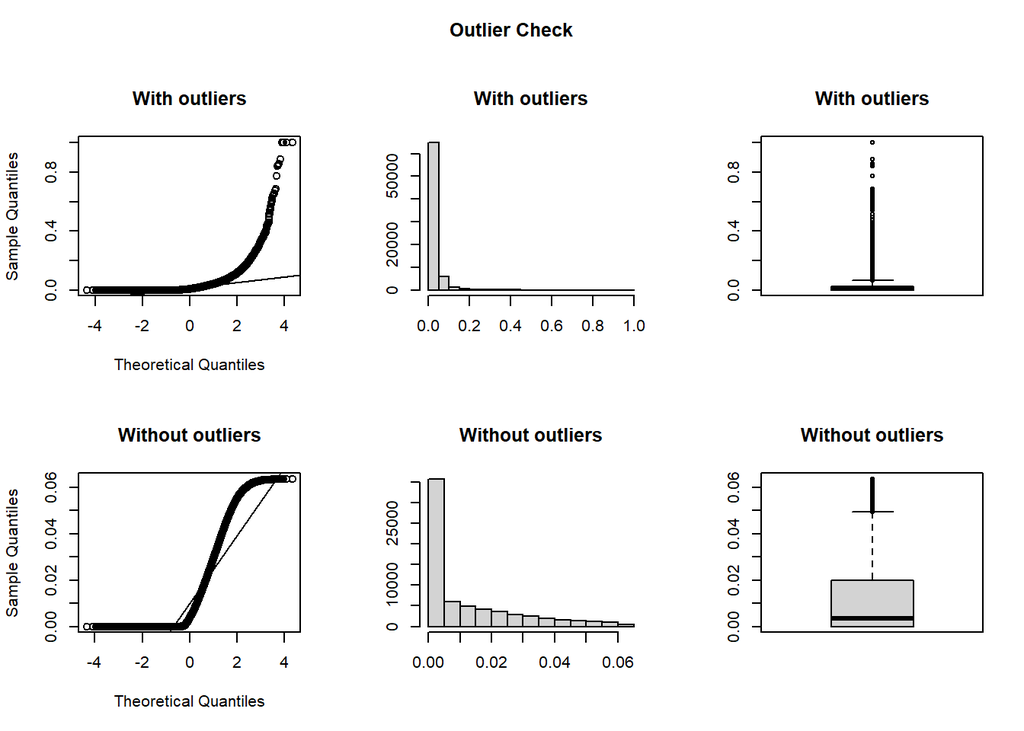

```
## Outliers identified: 5321
## Proportion (%) of outliers: 7.9
## Mean of the outliers: 0.11
## Mean without removing outliers: 0.02
## Mean if we remove outliers: 0.01
## Outliers successfully removed
```

```r
model_lila_1_10_var = c("Urban","GroupQuartersFlag","LowIncomeTracts","lahunv1share","PCTGQTRS","MedianFamilyIncome","lawhite1","lablack1","laasian1","lahisp1","lanhopi1","laomultir1","laaian1","lakids10","lakids1","TractKids","laseniors1","laseniors10","TractKids","TractSeniors","TractWhite","TractBlack","TractAsian","TractNHOPI","TractAIAN","TractOMultir","TractHispanic","TractHUNV","TractSNAP", "PovertyRate")
data$State  <- as.factor(data$State)
data$County  <- as.factor(data$County)
data$Urban <- as.factor(data$Urban)
data$GroupQuartersFlag <- as.factor(data$GroupQuartersFlag)
data$LILATracts_1And10 <-  as.factor(data$LILATracts_1And10)
data$LowIncomeTracts <- as.factor(data$LowIncomeTracts)
data$HUNVFlag= as.factor(data$HUNVFlag)
data$LATracts1 = as.factor(data$LATracts1)
data$LATractsVehicle_20 = as.factor(data$LATractsVehicle_20)
data <- ezids::outlierKD2(data, lahunv1share ,qqplt= TRUE, boxplt= TRUE, rm = TRUE)
```

```r
# Load necessary library
```

```r
# Create the formula for the glm model
formula_str <- paste("LILATracts_1And10 ~", paste(model_lila_1_10_var, collapse = " + "))

# Fit the GLM model
LILATracts_1And10_logit1 <- glm(as.formula(formula_str), data = data, family = binomial(link = "logit"))
```

```r
options(max.print = 1e6)
sum_LILATracts_1And10_logit1 = summary(LILATracts_1And10_logit1)
sum_LILATracts_1And10_logit1
```

```
##
## Call:
## glm(formula = as.formula(formula_str), family = binomial(link = "logit"),
##     data = data)
##
## Coefficients:
##                     Estimate Std. Error z value Pr(>|z|)
## (Intercept)        -2.65e+08   3.33e+05 -793.89  < 2e-16 ***
## Urban1              7.40e+01   2.25e+00   32.86  < 2e-16 ***
## GroupQuartersFlag1  1.77e+00   5.71e-01    3.10  0.00195 **
## LowIncomeTracts1    2.65e+08   3.33e+05  793.89  < 2e-16 ***
## lahunv1share        5.40e+01   4.05e+00   13.33  < 2e-16 ***
## PCTGQTRS            4.43e-01   6.10e-01    0.73  0.46764
## MedianFamilyIncome  5.01e-06   3.77e-06    1.33  0.18347
## lawhite1            5.56e-03   4.14e-04   13.41  < 2e-16 ***
## lablack1            7.70e-03   5.12e-04   15.05  < 2e-16 ***
## laasian1            3.25e-02   3.32e-03    9.81  < 2e-16 ***
## lahisp1             1.19e-03   6.98e-04    1.70  0.08933 .
## lanhopi1            1.38e-03   7.03e-03    0.20  0.84407
## laomultir1          8.48e-03   1.38e-03    6.16  7.3e-10 ***
## laaian1             5.75e-03   2.14e-03    2.69  0.00714 **
## lakids10            2.75e-01   1.26e-02   21.84  < 2e-16 ***
## lakids1            -3.50e-03   1.27e-03   -2.75  0.00597 **
## TractKids           4.09e-04   2.22e-04    1.84  0.06587 .
## laseniors1          2.20e-03   1.21e-03    1.82  0.06909 .
## laseniors10         3.24e-01   1.18e-02   27.40  < 2e-16 ***
## TractSeniors        1.85e-04   2.35e-04    0.78  0.43291
## TractWhite          1.25e-04   7.17e-05    1.74  0.08165 .
## TractBlack         -1.47e-04   8.82e-05   -1.67  0.09449 .
## TractAsian         -2.22e-03   3.85e-04   -5.76  8.6e-09 ***
## TractNHOPI         -1.64e-03   2.23e-03   -0.74  0.46203
## TractAIAN           5.12e-04   4.95e-04    1.03  0.30142
## TractOMultir       -2.73e-04   2.05e-04   -1.33  0.18274
## TractHispanic      -1.53e-04   8.53e-05   -1.79  0.07361 .
## TractHUNV          -3.92e-03   4.88e-04   -8.03  9.7e-16 ***
## TractSNAP           1.40e-03   3.74e-04    3.74  0.00019 ***
## PovertyRate        -1.44e-02   4.70e-03   -3.06  0.00224 **
## ---
## Signif. codes:  0 '***' 0.001 '**' 0.01 '*' 0.05 '.' 0.1 ' ' 1
##
## (Dispersion parameter for binomial family taken to be 1)
##
##     Null deviance: 43178.8  on 67542  degrees of freedom
## Residual deviance:  4260.4  on 67513  degrees of freedom
##   (5321 observations deleted due to missingness)
## AIC: 4320
##
## Number of Fisher Scoring iterations: 24
```

```r
#capture.output(sum_LILATracts_1And10_logit1, file = "models/glm_1_logit_lila1_10_summary.txt")
options(max.print = .Options$max.print)
```

The residual deviance decreased by a considerable amount indicating the model is better than a null model

```r
saveRDS(LILATracts_1And10_logit1, file = "glm_1_logit_lila1_10.rds")
```

### Summary of the model

```r
str(LILATracts_1And10_logit1$fitted.values)
```

```
##  Named num [1:67543] 2.22e-16 2.22e-16 2.22e-16 2.22e-16 2.22e-16 ...
##  - attr(*, "names")= chr [1:67543] "1" "2" "3" "4" ...
```

```r
summary(LILATracts_1And10_logit1$fitted.values)
```

```
##    Min. 1st Qu.  Median    Mean 3rd Qu.    Max.
## 0.00000 0.00000 0.00000 0.09754 0.00563 1.00000
```

```r
complete_cases <- complete.cases(data[model_lila_1_10_var])
sum(complete_cases)
```

```
## [1] 67543
```

### Removing the nan values

```r
sapply(data[model_lila_1_10_var], function(x) sum(is.na(x)))
```

```
##              Urban  GroupQuartersFlag    LowIncomeTracts       lahunv1share
##                  0                  0                  0               5321
##           PCTGQTRS MedianFamilyIncome           lawhite1           lablack1
##                  0                  0                  0                  0
##           laasian1            lahisp1           lanhopi1         laomultir1
##                  0                  0                  0                  0
##            laaian1           lakids10            lakids1          TractKids
##                  0                  0                  0                  0
##         laseniors1        laseniors10        TractKids.1       TractSeniors
##                  0                  0                  0                  0
##         TractWhite         TractBlack         TractAsian         TractNHOPI
##                  0                  0                  0                  0
##          TractAIAN       TractOMultir      TractHispanic          TractHUNV
##                  0                  0                  0                  0
##          TractSNAP        PovertyRate
##                  0                  0
```

```r
cleaned_data <- na.omit(data, cols = model_lila_1_10_var)
sapply(cleaned_data[model_lila_1_10_var], function(x) sum(is.na(x)))
```

```
##              Urban  GroupQuartersFlag    LowIncomeTracts       lahunv1share
##                  0                  0                  0                  0
##           PCTGQTRS MedianFamilyIncome           lawhite1           lablack1
##                  0                  0                  0                  0
##           laasian1            lahisp1           lanhopi1         laomultir1
##                  0                  0                  0                  0
##            laaian1           lakids10            lakids1          TractKids
##                  0                  0                  0                  0
##         laseniors1        laseniors10        TractKids.1       TractSeniors
##                  0                  0                  0                  0
##         TractWhite         TractBlack         TractAsian         TractNHOPI
##                  0                  0                  0                  0
##          TractAIAN       TractOMultir      TractHispanic          TractHUNV
##                  0                  0                  0                  0
##          TractSNAP        PovertyRate
##                  0                  0
```

### Accuracy and confusion matrix

```r
cm = table(cleaned_data$LILATracts_1And10,LILATracts_1And10_logit1$fitted.values>.5)
xkabledply( table(cleaned_data$LILATracts_1And10,LILATracts_1And10_logit1$fitted.values>.5), title = "Confusion matrix from Logit Model" )
```

Confusion matrix from Logit Model

|  | FALSE | TRUE |
| --- | --- | --- |
| 0 | 60838 | 117 |
| 1 | 326 | 6262 |

```r
precision_stepwise = cm[2,2]/(cm[2,2]+cm[1,2])
precision_stepwise
```

```
## [1] 0.98166
```

```r
recall_stepwise = cm[2,2]/(cm[2,2]+cm[2,1])
recall_stepwise
```

```
## [1] 0.95052
```

```r
accuracy_stepwise =  (cm[1,1]+cm[2,2])/(cm[1,1]+ cm[1,2]+cm[2,1] + cm[2,2])
accuracy_stepwise
```

```
## [1] 0.99344
```

The accuracy of the model is 0.99344.

### Receiver-Operator-Characteristic (ROC) curve and Area-Under-Curve (AUC)

```r
cleaned_data$prob=predict(LILATracts_1And10_logit1, type = c("response")) # Add new column of predicted probabilities
h <- roc(LILATracts_1And10~prob, data=cleaned_data)
auc(h)
```

```
## Area under the curve: 0.998
```

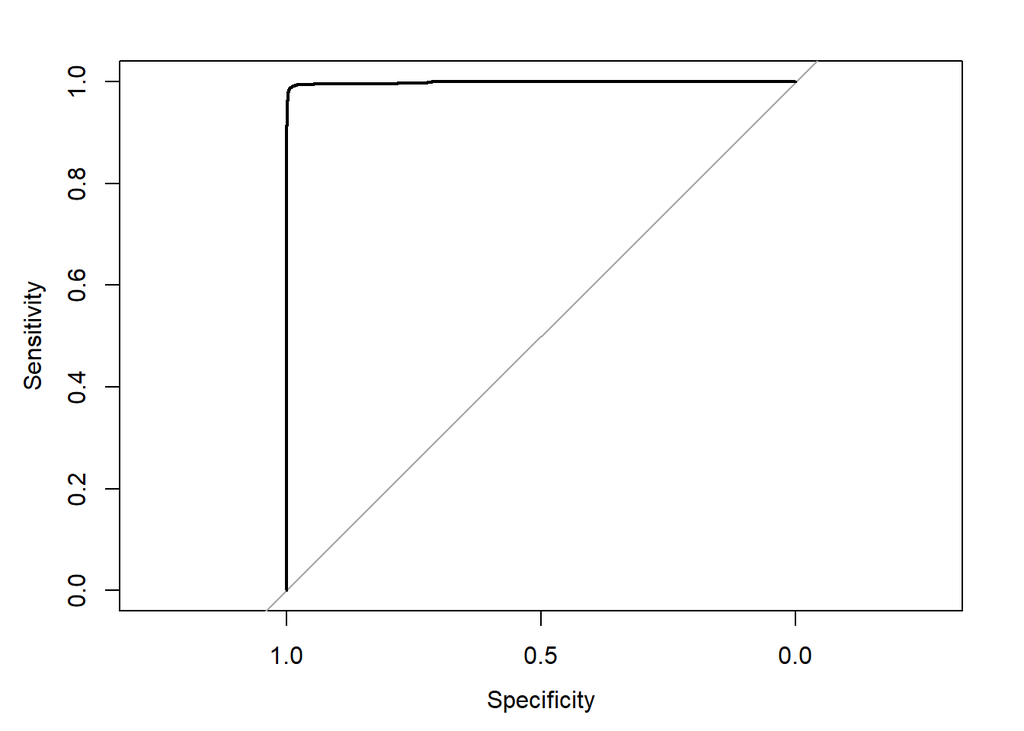

```r
plot(h)
```

```r
factors_LILATracts_1And10_logit1 = exp(coef(LILATracts_1And10_logit1))
factors_LILATracts_1And10_logit1
```

```
##        (Intercept)             Urban1 GroupQuartersFlag1   LowIncomeTracts1
##         0.0000e+00         1.4250e+32         5.8669e+00                Inf
##       lahunv1share           PCTGQTRS MedianFamilyIncome           lawhite1
##         2.8448e+23         1.5574e+00         1.0000e+00         1.0056e+00
##           lablack1           laasian1            lahisp1           lanhopi1
##         1.0077e+00         1.0331e+00         1.0012e+00         1.0014e+00
##         laomultir1            laaian1           lakids10            lakids1
##         1.0085e+00         1.0058e+00         1.3165e+00         9.9650e-01
##          TractKids         laseniors1        laseniors10       TractSeniors
##         1.0004e+00         1.0022e+00         1.3823e+00         1.0002e+00
##         TractWhite         TractBlack         TractAsian         TractNHOPI
##         1.0001e+00         9.9985e-01         9.9779e-01         9.9836e-01
##          TractAIAN       TractOMultir      TractHispanic          TractHUNV
##         1.0005e+00         9.9973e-01         9.9985e-01         9.9609e-01
##          TractSNAP        PovertyRate
##         1.0014e+00         9.8573e-01
```

```r
options(max.print = 1e6)
#capture.output(factors_LILATracts_1And10_logit1, file = "models/glm_1_logit_lila1_10_factors.txt")
```

Even though the model gave very good accuracy and AUC is near 1. The ROC curve is also in a perfect shape.

We understood all of this indicating some sort of overfitting or perfect separtion. So when we did exponents of the coefficient to find out the odds ratio factors, we found that for every unit increase in LowIncomeTracts1 will increase the odd ratio of being in a food desert by infinity, so we de decided to enquire about it and found out the LILATracts_1And10 is derived variable from LowIncomeTracts1 and that is why there is perfect separation. So we removed the LowIncomeTracts1 variable and then trained models for food desert. Being in urban has a huge impact in a tract being food desert.

### Train/Test Split

We split the data into train and test. Test set has 20% of data. This is to check overfitting and check the performance for unseen data.

```r
n <- nrow(cleaned_data)
# Calculate the size of the training set (e.g., 80% of the dataset)
trainSize <- floor(0.8 * n)
# Randomly sample row indices for the training set
trainIndex <- sample(seq_len(n), size = trainSize)
# Create training and test datasets
trainData <- cleaned_data[trainIndex, ]
testData <- cleaned_data[-trainIndex, ]
```

### Stepwise forward

In order to consider only the best variables for a model we used stepwise forward model building by including the previously considered variables but excluding the LowIncomeTracts1.

```r
print(stepwise_model$deviance)
```

```
## [1] 20012
```

```r
print(stepwise_model$null.deviance)
```

```
## [1] 34617
```

```r
pchisq(  stepwise_model$null.deviance - stepwise_model$deviance  , 54033 - 54010  , lower.tail = F )
```

```
## [1] 0
```

In addition we can also see the residual deviance is significantly lower than Null deviance. The chi-square test also indicates that the trained model is statistically better than the null model.

### Stepwise Coeff

```r
factors_stepwise_model = exp(coef(stepwise_model))
factors_stepwise_model
```

```
##        (Intercept)       lahunv1share MedianFamilyIncome             Urban1
##         7.2140e-03         1.7797e+35         9.9995e-01         4.8389e+01
##        laseniors10         laomultir1          TractHUNV          TractSNAP
##         1.0106e+00         1.0014e+00         9.9152e-01         1.0033e+00
##            lakids1         TractWhite           lablack1      TractHispanic
##         9.9896e-01         1.0004e+00         1.0006e+00         9.9966e-01
## GroupQuartersFlag1        PovertyRate            lahisp1         laseniors1
##         1.2543e-01         1.0170e+00         1.0006e+00         9.9887e-01
##          TractAIAN       TractSeniors       TractOMultir          TractKids
##         1.0007e+00         1.0004e+00         1.0004e+00         9.9963e-01
##         TractBlack           lakids10         TractAsian           laasian1
##         1.0001e+00         1.0008e+00         9.9978e-01         1.0004e+00
```

```r
options(max.print = 1e6)
```

[figure not shown]

```r
model_variable <- factors_stepwise_model[2:25]

variable_names <- names(model_variable)
variable_values <- unname(model_variable)

# "lahunv1share",    2.0088e+43
merged_df <- data.frame(Variable = variable_names, Importance = variable_values)
merged_df$Importance <- log(merged_df$Importance + 1)  # Adding 1 to avoid log(0) or log(negative values)
merged_df <- merged_df[order(merged_df$Importance), ]

bar_chart <- ggplot(merged_df, aes(x = variable_names, y = variable_values)) +
  geom_bar(stat = "identity", fill = "lightblue", width = 0.5) +
  labs(title = "Log odds ratio of model",
       x = "Variable",
       y = "Log odds") +
  theme_minimal() +
  theme(axis.text.x = element_text(angle = 90, hjust = 1, vjust=0.2))

options(
  repr.plot.width = 25,  # Set the desired width in inches
  repr.plot.height = 30  # Set the desired height in inches
)

print(bar_chart)
```

[figure not shown]

```r
model_variable <- factors_stepwise_model[3:25]

variable_names <- names(model_variable)
variable_values <- unname(model_variable)

# "lahunv1share",    2.0088e+43
merged_df <- data.frame(Variable = variable_names, Importance = variable_values)
merged_df$Importance <- log(merged_df$Importance + 1)  # Adding 1 to avoid log(0) or log(negative values)
merged_df <- merged_df[order(merged_df$Importance), ]

bar_chart <- ggplot(merged_df, aes(x = variable_names, y = variable_values)) +
  geom_bar(stat = "identity", fill = "lightblue", width = 0.5) +
  labs(title = "Log odds ratio of model after removing lahunv",
       x = "Variable",
       y = "Log odds") +
  theme_minimal() +
  theme(axis.text.x = element_text(angle = 90, hjust = 1, vjust=0.2))

options(
  repr.plot.width = 25,  # Set the desired width in inches
  repr.plot.height = 30  # Set the desired height in inches
)

print(bar_chart)
```

**SMART Question : What specific factors most significantly contribute to a tract being classified as a food desert?**

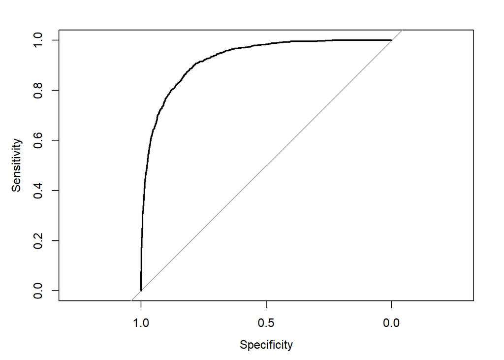

```r
#print(nrow(testData))
testData$prob=predict(stepwise_model, newdata = testData, type = c("response")) # Add new column of predicted probabilities

# Assuming testData is your data frame, and it has the actual classes in a binary column 'actual_class'
# and the predicted probabilities in a column 'predicted_prob'

h <- roc(LILATracts_1And10~prob, data=testData)
auc = auc(h)
plot(h)
```

The auc of the stepwise model is 0.92571. And now we see that AUC is reasonable and the ROC curve doesn’t indicate a perfect separation after removing the LowIncomeTract variable.

```r
sapply(testData[model_lila_1_10_var], function(x) sum(is.na(x)))
```

```
##              Urban  GroupQuartersFlag    LowIncomeTracts       lahunv1share
##                  0                  0                  0                  0
##           PCTGQTRS MedianFamilyIncome           lawhite1           lablack1
##                  0                  0                  0                  0
##           laasian1            lahisp1           lanhopi1         laomultir1
##                  0                  0                  0                  0
##            laaian1           lakids10            lakids1          TractKids
##                  0                  0                  0                  0
##         laseniors1        laseniors10        TractKids.1       TractSeniors
##                  0                  0                  0                  0
##         TractWhite         TractBlack         TractAsian         TractNHOPI
##                  0                  0                  0                  0
##          TractAIAN       TractOMultir      TractHispanic          TractHUNV
##                  0                  0                  0                  0
##          TractSNAP        PovertyRate
##                  0                  0
```

```r
#cleaned_data <- na.omit(data, cols = model_lila_1_10_var)
```

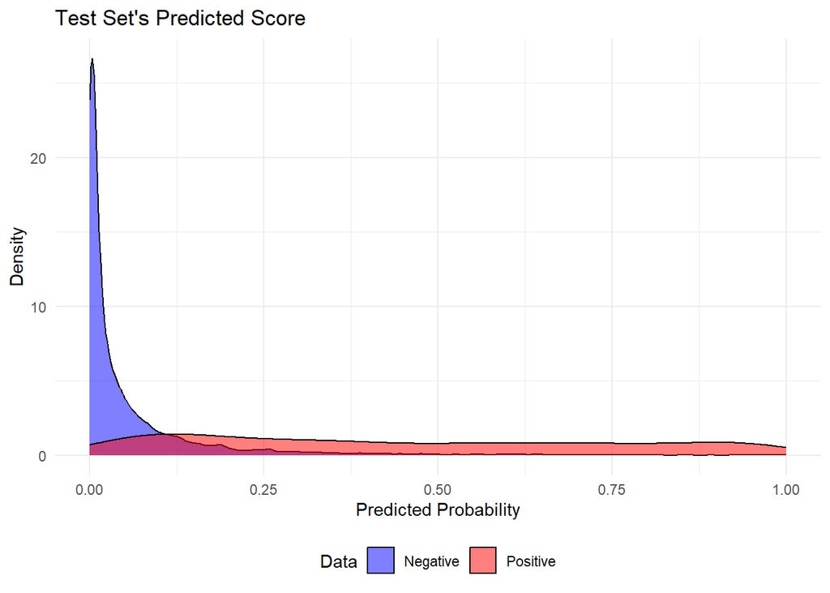

```r
testData$prob = predict(stepwise_model, newdata = testData, type = c("response"))

ggplot(testData, aes(x = prob, fill = as.factor(LILATracts_1And10))) +
geom_density(alpha = 0.5) +
scale_fill_manual(values = c("blue", "red"), labels = c("Negative", "Positive")) +
labs(title = "Test Set's Predicted Score",
x = "Predicted Probability",
y = "Density",
fill = "Data") +
theme_minimal() +
theme(legend.position = "bottom")
```

```r
cut_off = coords(h, "best", ret = "threshold")
print(cut_off[1, 'threshold'])
```

```
## [1] 0.08869
```

```r
cm = table(testData$LILATracts_1And10, (testData$prob > cut_off[1, 'threshold']))
cm
```

```
##
##     FALSE TRUE
##   0  9969 2239
##   1   163 1138
```

```r
precision_stepwise = cm[2,2]/(cm[2,2]+cm[1,2])
precision_stepwise
```

```
## [1] 0.33699
```

```r
recall_stepwise = cm[2,2]/(cm[2,2]+cm[2,1])
recall_stepwise
```

```
## [1] 0.87471
```

```r
accuracy_stepwise =  (cm[1,1]+cm[2,2])/(cm[1,1]+ cm[1,2]+cm[2,1] + cm[2,2])
accuracy_stepwise
```

```
## [1] 0.82219
```

- The probability density distribution of the results indicate that it is highly rightly skewed. This is because the data is highly unablanced.
- We got the best cut_off for our model from the youden’s index as 0.08869. We are focused on capturing as many food deserts from the prediction and so our key performance indicator is recall.
- The model gives a very good recall of 0.87471.

## CART Model for Food deserts.

### Classification and Regression Tree on Food deserts

We decide to create a CART model on the food deserts again to create a decision tree and help any decision maker to find out whether a place is food desert or not by asking few questions from the data. This also helps to compare the important factors between logistic regression and CART.

```r
# Assuming 'data' is your dataset and 'target' is your target variable
set.seed(123)  # for reproducibility
# Custom summary function
# Define control method for cross-validation
fitControl <- trainControl(method = "cv",   number = 10)    # number of folds
formula_str_3 <- paste("LILATracts_1And10 ~", paste(model_lila_1_10_var_stepwise, collapse = " + "))
# Convert the string to a formula object
##### full regression tree
formula_obj_3 <- as.formula(formula_str_3)
# Train the model
lila_cart_model <- train(formula_obj_3, data = trainData,method = "rpart",trControl = fitControl)
# Summary of the model performance
print(lila_cart_model)
```

```
## CART
##
## 54034 samples
##    28 predictor
##     2 classes: '0', '1'
##
## No pre-processing
## Resampling: Cross-Validated (10 fold)
## Summary of sample sizes: 48630, 48630, 48630, 48631, 48631, 48631, ...
## Resampling results across tuning parameters:
##
##   cp        Accuracy  Kappa
##   0.027804  0.95392   0.74077
##   0.042746  0.95066   0.71547
##   0.159952  0.93891   0.55416
##
## Accuracy was used to select the optimal model using the largest value.
## The final value used for the model was cp = 0.027804.
```

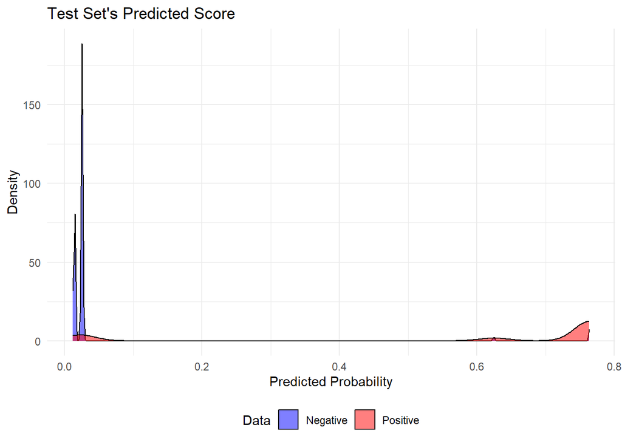

```r
########## LILA CV

testData$treeLilaCVModelProb <- predict(lila_cart_model, newdata = testData, type = "prob")[,2]
ggplot(testData, aes(x = treeLilaCVModelProb, fill = as.factor(LILATracts_1And10))) +
geom_density(alpha = 0.5) +
scale_fill_manual(values = c("blue", "red"), labels = c("Negative", "Positive")) +
labs(title = "Test Set's Predicted Score",
x = "Predicted Probability",
y = "Density",
fill = "Data") +
theme_minimal() +
theme(legend.position = "bottom")
```

```r
#print(cleaned_data$prob)
# Add new column of predicted probabilities
h <- roc(LILATracts_1And10~treeLilaCVModelProb, data=testData)
auc(h)
```

```
## Area under the curve: 0.891
```

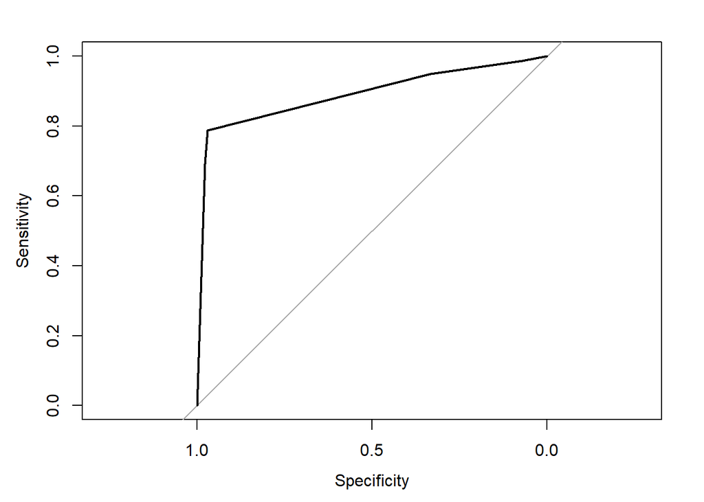

```r
plot(h)
```

```r
coords(h, "best", ret = "threshold")
```

```
##   threshold
## 1   0.32506
```

```r
cm = table(testData$LILATracts_1And10,testData$treeLilaCVModelProb >0.074475)
cm
```

```
##
##     FALSE  TRUE
##   0 11832   376
##   1   276  1025
```

```r
precision_cart = cm[2,2]/(cm[2,2]+cm[1,2])
precision_cart
```

```
## [1] 0.73162
```

```r
recall_cart = cm[2,2]/(cm[2,2]+cm[2,1])
recall_cart
```

```
## [1] 0.78786
```

```r
accuracy_cart =  (cm[1,1]+cm[2,2])/(cm[1,1]+ cm[1,2]+cm[2,1] + cm[2,2])
accuracy_cart
```

```
## [1] 0.95174
```

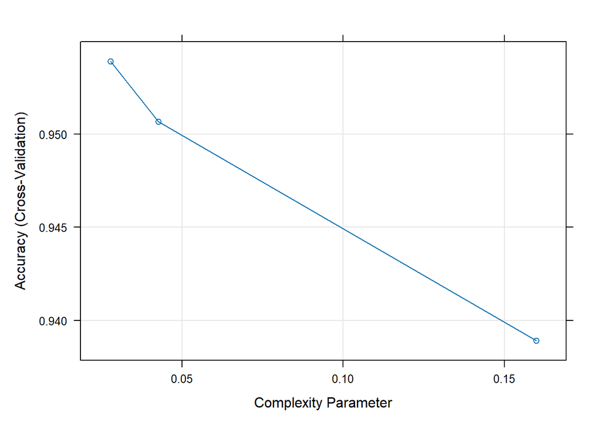

```r
#print(testData$pred)
plot(lila_cart_model)
```

```r
varImp(lila_cart_model)
```

```
## rpart variable importance
##
##   only 20 most important variables shown (out of 28)
##
##                    Overall
## lakids1            100.000
## laomultir1          86.274
## laseniors1          82.802
## lawhite1            80.932
## Urban1              61.337
## lahisp1             59.663
## PovertyRate         44.518
## MedianFamilyIncome  42.266
## lahunv1share        24.785
## laseniors10         18.497
## lakids10            18.045
## laaian1              0.897
## TractBlack           0.723
## TractAsian           0.000
## TractKids            0.000
## TractHispanic        0.000
## TractAIAN            0.000
## laasian1             0.000
## TractOMultir         0.000
## TractSNAP            0.000
```

```r
print(lila_cart_model)
```

```
## CART
##
## 54034 samples
##    28 predictor
##     2 classes: '0', '1'
##
## No pre-processing
## Resampling: Cross-Validated (10 fold)
## Summary of sample sizes: 48630, 48630, 48630, 48631, 48631, 48631, ...
## Resampling results across tuning parameters:
##
##   cp        Accuracy  Kappa
##   0.027804  0.95392   0.74077
##   0.042746  0.95066   0.71547
##   0.159952  0.93891   0.55416
##
## Accuracy was used to select the optimal model using the largest value.
## The final value used for the model was cp = 0.027804.
```

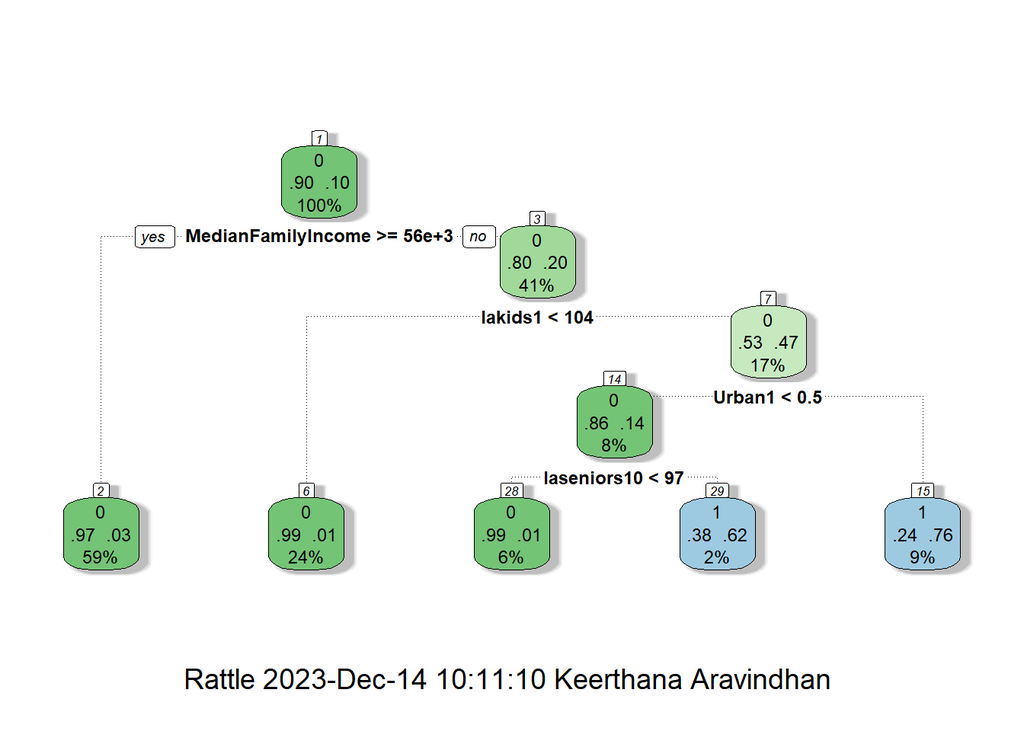

```r
fancyRpartPlot(lila_cart_model$finalModel)
```

## Comparison of CART and Logistic Metrics.

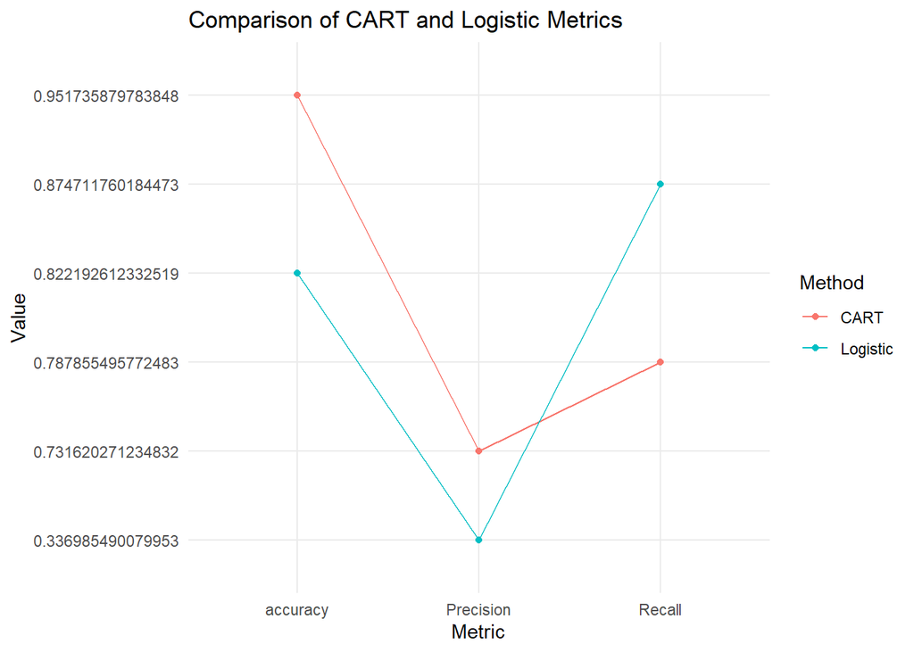

```r
metrics_data_LILA = data.frame()
metrics_data_LILA <- rbind(metrics_data_LILA, c("CART", "accuracy", accuracy_cart))
metrics_data_LILA <- rbind(metrics_data_LILA, c("CART", "Precision", precision_cart))
metrics_data_LILA <- rbind(metrics_data_LILA, c("CART", "Recall", recall_cart))
metrics_data_LILA <- rbind(metrics_data_LILA, c("Logistic", "accuracy", accuracy_stepwise))
metrics_data_LILA <- rbind(metrics_data_LILA, c("Logistic", "Precision", precision_stepwise))
metrics_data_LILA <- rbind(metrics_data_LILA, c("Logistic", "Recall", recall_stepwise))
colnames(metrics_data_LILA) <- c('Method', 'Metric', 'Value')

# Create the line graph using ggplot2
ggplot(metrics_data_LILA, aes(x = Metric, y = Value, group = Method, color = Method)) +
  geom_line() +
  geom_point() +
  labs(title = "Comparison of CART and Logistic Metrics",
       x = "Metric",
       y = "Value") +
  theme_minimal()
```

## Best model for Food desert

- From the model comparison we found that stepwise logistic regression performs better for food desert prediction compared to CART.
- Our smart question are more prediction related and our final recall score for best stepwise logistic mode for the food desert is 0.87471. Our predictions are very good.

# EDA and inference of Poverty rate:

## Impact of Low income tracts on Poverty Rate.

### Graph analysis:

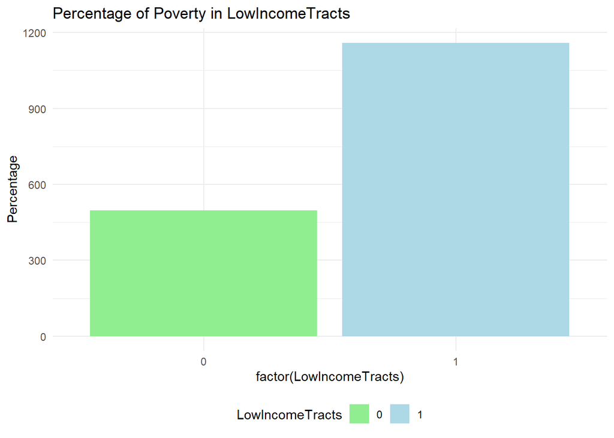

```r
data2 = data.frame()
Percentage_LowIncomeTracts_Poverty = sum(LowIncomeTracts_Poverty$PovertyRate)/(sum(nrow(LowIncomeTracts_Poverty)+ nrow(NonLowIncomeTracts_Poverty)))*100
Percentage_NonLowIncomeTracts_Poverty = sum(NonLowIncomeTracts_Poverty$PovertyRate)/(sum(nrow(LowIncomeTracts_Poverty)+ nrow(NonLowIncomeTracts_Poverty)))*100
data2 <- rbind(data2, Percentage_LowIncomeTracts_Poverty)
data2 <- rbind(data2, Percentage_NonLowIncomeTracts_Poverty)
LowIncomeTracts = c(1,0)
data2 <- cbind(data2, LowIncomeTracts)
colnames(data2) <- c('Percentage', 'LowIncomeTracts')

library(ggplot2)
ggplot(data2, aes(x = factor(LowIncomeTracts), y = Percentage, fill = factor(LowIncomeTracts))) +
  geom_bar(stat = "identity", position = "dodge") +
  scale_fill_manual(values = c("0" = "lightgreen", "1" = "lightblue")) +
  labs(title = "Percentage of Poverty in LowIncomeTracts",
       fill = "LowIncomeTracts") +
  theme_minimal() +
  theme(legend.position = "bottom")
```

### Inference on effect of LowIncomeTracts on Poverty rate:

```r
model5 <- lm(PovertyRate ~ LowIncomeTracts, data = data)
summary(model5)
```

```
##
## Call:
## lm(formula = PovertyRate ~ LowIncomeTracts, data = data)
##
## Residuals:
##    Min     1Q Median     3Q    Max
## -27.36  -5.26  -1.03   4.27  72.64
##
## Coefficients:
##                  Estimate Std. Error t value Pr(>|t|)
## (Intercept)        8.6344     0.0440     196   <2e-16 ***
## LowIncomeTracts1  18.7235     0.0676     277   <2e-16 ***
## ---
## Signif. codes:  0 '***' 0.001 '**' 0.01 '*' 0.05 '.' 0.1 ' ' 1
##
## Residual standard error: 9.02 on 72862 degrees of freedom
## Multiple R-squared:  0.513,  Adjusted R-squared:  0.513
## F-statistic: 7.67e+04 on 1 and 72862 DF,  p-value: <2e-16
```

In this case, it suggests that when “LowIncomeTracts” is 1 (compared to 0), the estimated poverty rate increases by approximately 18.72349 units.

**The model indicates that the presence of low-income tracts (LowIncomeTracts1) is a statistically significant predictor of the poverty rate.**

## Impact of Food desert on Poverty Rate.

```r
model6 <- lm(PovertyRate ~ LILATracts_1And10, data = data)
summary(model6)
```

```
##
## Call:
## lm(formula = PovertyRate ~ LILATracts_1And10, data = data)
##
## Residuals:
##    Min     1Q Median     3Q    Max
## -26.48  -8.73  -3.23   4.87  84.87
##
## Coefficients:
##                    Estimate Std. Error t value Pr(>|t|)
## (Intercept)          15.126      0.049   308.8   <2e-16 ***
## LILATracts_1And101   11.359      0.138    82.6   <2e-16 ***
## ---
## Signif. codes:  0 '***' 0.001 '**' 0.01 '*' 0.05 '.' 0.1 ' ' 1
##
## Residual standard error: 12.4 on 72862 degrees of freedom
## Multiple R-squared:  0.0856, Adjusted R-squared:  0.0856
## F-statistic: 6.82e+03 on 1 and 72862 DF,  p-value: <2e-16
```

It suggests that when “LILATracts_1And10” changes from 0 to 1, the estimated poverty rate increases by approximately 11.35890 units.

**The coefficient for “LILATracts_1And101” suggests a positive association between the presence of such tracts and the poverty rate.**

# Predicting Poverty Rate

## Poverty rate using CART

As the poverty rate is related to food desert through government policies. We analysed poverty rate and also created a models to predict poveryrate.

We created a CART model on the Poverty Rate to create a decision tree and help any decision maker to find out whether a place is Povery rate or not by asking few questions from the data.

```r
#Poverty Rate
model_pov_rate_columns =  c("LILATracts_1And10","Urban",
"GroupQuartersFlag","LowIncomeTracts","lahunv1share","PCTGQTRS","MedianFamilyIncome","lawhite1","lablack1","laasian1","lahisp1","lanhopi1","laomultir1","laaian1","lakids10","lakids1","TractKids","laseniors1","laseniors10","TractKids","TractSeniors","TractWhite","TractBlack","TractAsian","TractNHOPI","TractAIAN","TractOMultir","TractHispanic","TractHUNV","TractSNAP")
print(head(cleaned_data))
```

[output not shown]

[output cut: 160 more lines]

```r
sapply(cleaned_data[model_lila_1_10_var], function(x) sum(is.na(x)))
```

```
##              Urban  GroupQuartersFlag    LowIncomeTracts       lahunv1share
##                  0                  0                  0                  0
##           PCTGQTRS MedianFamilyIncome           lawhite1           lablack1
##                  0                  0                  0                  0
##           laasian1            lahisp1           lanhopi1         laomultir1
##                  0                  0                  0                  0
##            laaian1           lakids10            lakids1          TractKids
##                  0                  0                  0                  0
##         laseniors1        laseniors10        TractKids.1       TractSeniors
##                  0                  0                  0                  0
##         TractWhite         TractBlack         TractAsian         TractNHOPI
##                  0                  0                  0                  0
##          TractAIAN       TractOMultir      TractHispanic          TractHUNV
##                  0                  0                  0                  0
##          TractSNAP        PovertyRate
##                  0                  0
```

Here we consider the lowincometract variable because poveryrate is not derived from lowincometract.

### Adjusted R2 method for Poverty Rate

```r
adjustedR2 <- function(data, p = NULL, model = NULL) {
pred <- data$pred
obs <- data$PovertyRate
n <- length(obs)
#p <- model$finalModel$terms$term.labels # number of predictors
# Assuming 'model' is your trained model
#p <- length(all.vars(model$finalModel$call$formula)) - 1
rss <- sum((pred - obs) ^ 2)
tss <- sum((obs - mean(obs)) ^ 2)
#print(tss)
#print(rss)
#print(p)
adjR2 <- 1 - (rss/(n-p-1))/(tss/(n-1))
adjR2
}
```

```r
# Assuming 'data' is your dataset and 'target' is your target variable
set.seed(123)  # for reproducibility
# Custom summary function
# Define control method for cross-validation
fitControl <- trainControl(method = "cv",  # k-fold cross-validation
number = 10)    # number of folds
formula_str_3 <- paste("PovertyRate ~", paste(model_pov_rate_columns, collapse = " + "))
# Convert the string to a formula object
##### full regression tree
formula_obj_3 <- as.formula(formula_str_3)
# Train the model
povCARTModel <- train(formula_obj_3, data = trainData,
method = "rpart",
trControl = fitControl)
# Summary of the povCARTModel performance
print(povCARTModel)
```

```
## CART
##
## 54034 samples
##    29 predictor
##
## No pre-processing
## Resampling: Cross-Validated (10 fold)
## Summary of sample sizes: 48629, 48631, 48630, 48630, 48630, 48633, ...
## Resampling results across tuning parameters:
##
##   cp        RMSE     Rsquared  MAE
##   0.032137   6.9256  0.69595   5.1762
##   0.170810   7.9974  0.59130   5.7676
##   0.510167  10.6875  0.50615   7.9039
##
## RMSE was used to select the optimal model using the smallest value.
## The final value used for the model was cp = 0.032137.
```

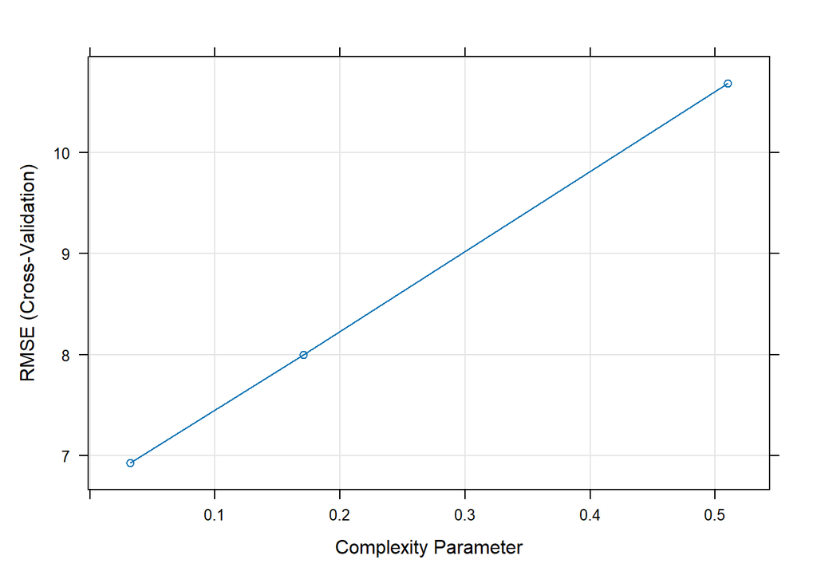

```r
plot(povCARTModel)
```

```r
varImp(povCARTModel)
```

```
## rpart variable importance
##
##   only 20 most important variables shown (out of 29)
##
##                    Overall
## MedianFamilyIncome  100.00
## LowIncomeTracts1     58.26
## TractSNAP            38.26
## TractHUNV            29.21
## TractBlack           12.72
## TractSeniors         11.76
## TractWhite            9.29
## lahisp1               0.00
## lawhite1              0.00
## lakids10              0.00
## laomultir1            0.00
## lahunv1share          0.00
## laaian1               0.00
## TractKids             0.00
## laseniors10           0.00
## GroupQuartersFlag1    0.00
## TractAIAN             0.00
## laseniors1            0.00
## TractOMultir          0.00
## lablack1              0.00
```